```python
import numpy as np
import pandas as pd
import statsmodels.api as sm
import pandas_datareader as pdr
import matplotlib.pyplot as plt
import statsmodels.tsa.api as tsa
PLOT_STYLE = "seaborn-colorblind"

import warnings
warnings.filterwarnings("ignore")
```

# Time Series - AR

## PACF plots for the daily log returns

```python
adjclose = pdr.get_data_yahoo("aapl", "2019-03-16", "2022-03-16")["Adj Close"]
logret = np.log(adjclose/adjclose.shift(1)).dropna()
```

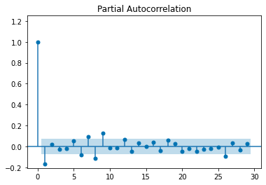

```python
with plt.style.context(PLOT_STYLE):
    fig, ax = plt.subplots(1, 1)
    # auto_ylims
    tsa.graphics.plot_pacf(logret, method="yw", ax=ax, auto_ylims=True)
```

```python
X = logret.loc['2019-03-16':'2021-03-16']
y = logret.loc['2021-03-17':'2022-03-16']
```

## Two approaches to estiamte the AR model

### Yule-Walker

First, apply the Yule-Walker equations to estimate the AR coefficients. The method returns the coefficients as well as the sigma of the residuals. By default, this method will remove the mean beforeing fitting, and there is no constant term.

Reference: https://www.statsmodels.org/devel/generated/statsmodels.regression.linear_model.yule_walker.html#statsmodels.regression.linear_model.yule_walker

$$ \widehat{\phi}=\mathbf{R}^{-1} \mathbf{r} $$

The method returns the $\widehat{\phi}$, not $\mathbf{R}$, though variable is called so. The $\mathbf{R}$ and $\mathbf{r}$ are estimated by Yule-Walker.

```python
rho, sigma = sm.regression.yule_walker(X, order=9, method="mle")
```

```python
print("The coefficients of AR(9) model, fitted by Yule-Walker.")
print(rho)
```

```
The coefficients of AR(9) model, fitted by Yule-Walker.
[-0.15326416  0.00625946  0.01964356 -0.02028379  0.02395939 -0.08346254
  0.08615506 -0.08927608  0.15616983]
```

```python
sigma
```

```
0.02257395886693094
```

### Least Squares

Then, apply the AutoReg method (least square estimates). The coefficients obtained are very close, except for the second one (close to zero, trivial). Also, the sigmas from both residuals are close

Reference: https://www.statsmodels.org/devel/generated/statsmodels.tsa.ar_model.AutoReg.html#statsmodels.tsa.ar_model.AutoReg

```python
from statsmodels.tsa.ar_model import AutoReg
ar_ols = AutoReg(X, lags = range(1,10)).fit()
```

```python
print("The coefficients of AR(9) model, fitted by Least Squares.")
ar_ols.params
```

```
The coefficients of AR(9) model, fitted by Least Squares.
```

```
const           0.002089
Adj Close.L1   -0.152338
Adj Close.L2    0.008230
Adj Close.L3    0.023569
Adj Close.L4   -0.021845
Adj Close.L5    0.024433
Adj Close.L6   -0.086268
Adj Close.L7    0.089491
Adj Close.L8   -0.092066
Adj Close.L9    0.161035
dtype: float64
```

```python
np.std(ar_ols.resid)
```

```
0.022649010745273625
```

### Predictions

The predictions using least squares are relatively easy.

```python
pred_ols = ar_ols.predict(start = len(X) + 1, end = len(y) + len(X))
```

**Comments before predicting by Yule-Walker**

- The Yule-Walker method does not offer the predict function, so we will substitue its parameters into a AutoReg model, and utilize the prediction functions from there.
- Also, by default Yule-Walker deducts the mean of the series before fitting. So we will add the mean of log returns back after the prediction.

```python
import copy
ar_yw = copy.deepcopy(ar_ols)
ar_yw.params[0] = 0 #reset the consant to 0
for i in range(1, 10):
    ar_yw.params[i] = rho[i-1]
```

```python
ar_yw.params
```

```
const           0.000000
Adj Close.L1   -0.153264
Adj Close.L2    0.006259
Adj Close.L3    0.019644
Adj Close.L4   -0.020284
Adj Close.L5    0.023959
Adj Close.L6   -0.083463
Adj Close.L7    0.086155
Adj Close.L8   -0.089276
Adj Close.L9    0.156170
dtype: float64
```

```python
pred_yw = ar_yw.predict(start = len(X) + 1, end = len(y) + len(X)) + np.mean(X)
```

**Load another predictions on the same data set that we have obtained before, and compare the results**

```python
pred_2e = pd.Series(np.load("preds_2e.npy"))
```

```python
pred_2e.index = pred_ols.index
```

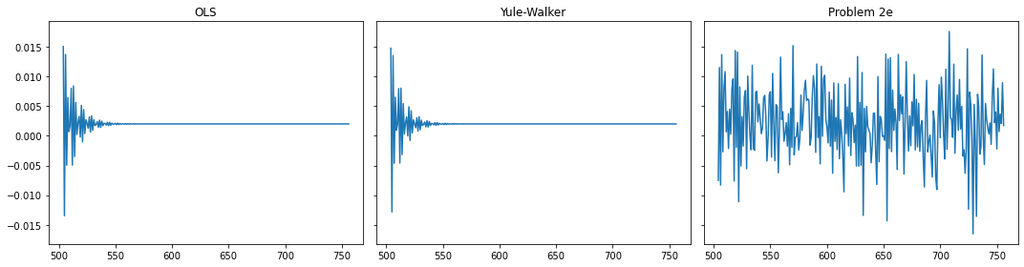

```python
fig, axs = plt.subplots(1, 3, sharex=True, sharey=True, figsize = (15,4))
axs[0].plot(pred_ols);
axs[0].set_title("OLS");
axs[1].plot(pred_yw);
axs[1].set_title("Yule-Walker");
axs[2].plot(pred_2e);
axs[2].set_title("Problem 2e");
plt.tight_layout()
```

```python
from sklearn.metrics import mean_squared_error
print("OLS: ", mean_squared_error(y, pred_ols))
print("Yule-Walker: ", mean_squared_error(y, pred_yw))
print("Problem 2e: ", mean_squared_error(y, pred_2e))
```

```
OLS:  0.00023772875933569045
Yule-Walker:  0.0002375987341581026
Problem 2e:  0.00027102017846111477
```

**Comments**

1. The predictions from two AR approaches are almost the same
2. The AR models have lower MSE than our linear prediction in Problem 2e